# Data Analytics for Finance

BM17FI · Rotterdam School of Management

[figure not shown]

ASSIGNMENT 03

## Setup

Run these cells to prepare your environment.

```
✅ The environment is cleared and ready.
```

```
checking estout consistency and verifying not already installed...
all files already exist and are up to date.
✅ The estout package is installed.
```

```
/Users/casparm4/Github/rsm-data-analytics-in-finance-private/private/assignment
> s/03-assignment
📁 Base directory: /Users/casparm4/Github/rsm-data-analytics-in-finance-private
> /private/assignments/03-assignment
📁 Raw data folder: /Users/casparm4/Github/rsm-data-analytics-in-finance-privat
> e/private/assignments/03-assignment/data/raw
📁 Output directory: /Users/casparm4/Github/rsm-data-analytics-in-finance-priva
> te/private/assignments/03-assignment/output
📁 Tables folder: /Users/casparm4/Github/rsm-data-analytics-in-finance-private/
> private/assignments/03-assignment/output/tables
📁 Figures folder: /Users/casparm4/Github/rsm-data-analytics-in-finance-private
> /private/assignments/03-assignment/output/figures
```

## Learning Objectives

By completing this assignment, you will:

1. **Estimate OLS regressions** using the `regress` command
2. **Interpret coefficients** economically and statistically
3. **Test OLS assumptions** (heteroskedasticity, normality of residuals)
4. **Apply robust standard errors** when heteroskedasticity is detected
5. **Create publication-quality regression tables** using `esttab`

## Research Question

> *"What firm characteristics explain the cross-sectional variation in stock price reactions to the Dieselgate scandal?"*

Specifically, we want to know:

- Did **German automakers** experience more negative abnormal returns than other automotive firms?
- Can this effect be explained by **firm characteristics** such as size, leverage, and profitability?

## Background: Event Study and Abnormal Returns

ℹ️ Background

**What are Cumulative Abnormal Returns (CARs)?**  
An **abnormal return (AR)** is the difference between a stock's actual return and its *expected return* based on market movements:  
`ARt = Rt - E[Rt]`  
Where:

- **R<sub>t</sub>** = Actual return on day t
- **E[R<sub>t</sub>]** = Expected return from market model (α + β × Market Return)

The **Cumulative Abnormal Return (CAR)** sums abnormal returns over an event window:  
`CAR[0,5] = AR0 + AR1 + AR2 + AR3 + AR4 + AR5`  
**Interpretation**: A CAR of -0.15 means the stock underperformed its expected return by 15 percentage points during the event window.  
In this assignment, **CARs have been pre-calculated** using the **market model with Fama-French Europe factors**. See the codebook for methodology details. We will come back to this in more detail in assignment 5.

📝 Tasks

In this assignment, you will complete the following graded tasks:

1. Load and examine the cross-sectional dataset
2. Perform exploratory analysis (correlations and scatter plots)
3. Estimate a baseline OLS regression
4. Add control variables and compare models
5. Test for heteroskedasticity (Breusch-Pagan test)
6. Test for normality of residuals (Shapiro-Wilk test)
7. Re-estimate with robust standard errors
8. Export a publication-quality regression table
9. Interpret your findings

## Section 1: Load and Examine Data

In this section, you'll load the cross-sectional dataset and examine its structure.

### Task 1.1: Load the Dataset

Load the file auto_firms_event_crosssection.dta from the raw data folder.

[figure not shown]

Stata Tip

Use `use "$raw/filename.dta", clear` to load a Stata dataset.

```
✅ Dataset loaded successfully
```

### Task 1.2: Examine the Dataset

Use describe to examine the structure of the dataset. How many observations? How many variables?

```
Contains data from /Users/casparm4/Github/rsm-data-analytics-in-finance-private
> /private/assignments/03-assignment/data/raw/auto_firms_event_crosssection.dta
 Observations:            84
    Variables:            24                  06 Jan 2026 15:08
-------------------------------------------------------------------------------
Variable      Storage   Display    Value
    name         type    format    label      Variable label
-------------------------------------------------------------------------------
gvkey           str6    %-9s
conm            str28   %-9s
fic             str3    %-9s
german          long    %12.0g
car_0_5         double  %10.0g
car_0_10        double  %10.0g
log_at          double  %10.0g
leverage        double  %10.0g
roa             double  %10.0g
debt_equity     double  %10.0g
roe             double  %10.0g
margin          double  %10.0g
cash_ratio      double  %10.0g
at              double  %10.0g
sale            double  %10.0g
dltt            double  %10.0g
dlc             double  %10.0g
ceq             double  %10.0g
ebitda          double  %10.0g
ib              double  %10.0g
oibdp           double  %10.0g
che             double  %10.0g
n_days_0_5      long    %12.0g
n_days_0_10     long    %12.0g
-------------------------------------------------------------------------------
Sorted by:
```

### Task 1.3: Summary Statistics

Generate summary statistics for the key variables: car_0_5, car_0_10, german, log_at, leverage, and roa.

[figure not shown]

Stata Tip

Use `summarize varlist` to show mean, SD, min, and max for specified variables.

```
    Variable |        Obs        Mean    Std. dev.       Min        Max
-------------+---------------------------------------------------------
     car_0_5 |         84   -.0074558    .0727016  -.3523587   .2633667
    car_0_10 |         84    .0072848    .1414629  -.8872483   .2801222
      german |         84    .0833333    .2780454          0          1
      log_at |         84    10.36085    3.473371   2.858938   18.80747
    leverage |         84    .2161082    .1966058          0   .9964587
-------------+---------------------------------------------------------
         roa |         84    .0615514    .1036582  -.4132906   .3438476
```

### Test: Dataset Loaded Correctly

```
✅ Dataset has correct number of observations
```

## Section 2: Exploratory Analysis

Before running regressions, let's explore the relationships between variables using correlations and scatter plots.

### Task 2.1: Correlation Matrix

Calculate the correlation matrix for car_0_5, german, log_at, leverage, and roa.  
Question: Is car_0_5 negatively correlated with german? What does this suggest?

[figure not shown]

Stata Tip

Use `correlate varlist` to display a correlation matrix.

```
(obs=84)

             |  car_0_5   german   log_at leverage      roa
-------------+---------------------------------------------
     car_0_5 |   1.0000
      german |  -0.4954   1.0000
      log_at |  -0.2459  -0.0106   1.0000
    leverage |   0.0084   0.0700   0.0684   1.0000
         roa |  -0.0652   0.0153   0.3246  -0.3275   1.0000
```

### Task 2.2: Scatter Plot - CAR vs German

Create a scatter plot of car_0_5 (y-axis) against german (x-axis). Add proper axis labels and title. Save as scatter_car_german.png.

```
file /Users/casparm4/Github/rsm-data-analytics-in-finance-private/private/assig
> nments/03-assignment/output/figures/scatter_car_german.png written in PNG for
> mat
✅ Scatter plot saved: scatter_car_german.png
```

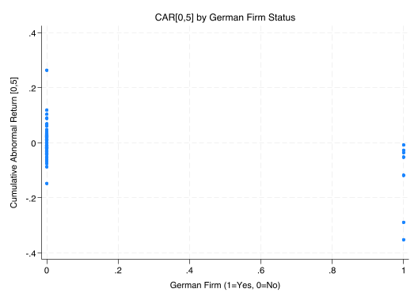

### Task 2.3: Scatter Plot - CAR vs Size

Create a scatter plot of car_0_5 (y-axis) against log_at (x-axis). Save as scatter_car_size.png.

```
file /Users/casparm4/Github/rsm-data-analytics-in-finance-private/private/assig
> nments/03-assignment/output/figures/scatter_car_size.png written in PNG forma
> t
✅ Scatter plot saved: scatter_car_size.png
```

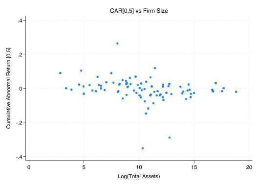

### Test: Exploratory Analysis Complete

```
✅ Exploratory analysis plots created successfully
```

## Section 3: Baseline OLS Regression

Now let's estimate a simple regression to test whether German firms experienced more negative CARs.

### Task 3.1: Estimate Baseline Model

Estimate the regression: car_0_5 = β₀ + β₁×german + ε  
Store the estimates with name m1 for later comparison.  
Questions to consider:

- What is the coefficient on `german`? Is it statistically significant?
- What does this coefficient mean economically?
- What is the R-squared? What does it tell us?

[figure not shown]

Stata Tip

- `regress depvar indepvars` — OLS regression
- `estimates store name` — Save estimates for later use

```
      Source |       SS           df       MS      Number of obs   =        84
-------------+----------------------------------   F(1, 82)        =     26.68
       Model |  .107686651         1  .107686651   Prob > F        =    0.0000
    Residual |  .331011944        82  .004036731   R-squared       =    0.2455
-------------+----------------------------------   Adj R-squared   =    0.2363
       Total |  .438698595        83  .005285525   Root MSE        =    .06354

------------------------------------------------------------------------------
     car_0_5 | Coefficient  Std. err.      t    P>|t|     [95% conf. interval]
-------------+----------------------------------------------------------------
      german |  -.1295467   .0250819    -5.16   0.000    -.1794425   -.0796508
       _cons |   .0033398   .0072405     0.46   0.646    -.0110639    .0177435
------------------------------------------------------------------------------
✅ Baseline model (m1) estimated and stored
```

### Test: Baseline Regression

```
✅ Baseline regression has expected properties
```

## Section 4: Add Control Variables

The baseline model might suffer from **omitted variable bias**. Let's add control variables for firm characteristics.

ℹ️ Background: Why Add Controls?

**Omitted variable bias** occurs when we leave out relevant variables that are correlated with both the treatment (German) and the outcome (CAR).  
For example:

- **Size (log_at)**: Larger firms might have more diversified operations and be less affected by single-country scandals
- **Leverage**: Highly leveraged firms might be more vulnerable to negative shocks
- **Profitability (roa)**: More profitable firms might weather bad news better

By including these controls, we can isolate the effect of being German, *holding constant* these other firm characteristics.

### Task 4.1: Regression with Controls

Estimate the regression: car_0_5 = β₀ + β₁×german + β₂×log_at + β₃×leverage + β₄×roa + ε  
Store the estimates with name m2.  
Questions to consider:

- Did the coefficient on `german` change compared to the baseline model?
- What does this tell us about omitted variable bias?
- Did the R-squared improve? By how much?

```
      Source |       SS           df       MS      Number of obs   =        84
-------------+----------------------------------   F(4, 79)        =      9.08
       Model |  .138161095         4  .034540274   Prob > F        =    0.0000
    Residual |    .3005375        79  .003804272   R-squared       =    0.3149
-------------+----------------------------------   Adj R-squared   =    0.2802
       Total |  .438698595        83  .005285525   Root MSE        =    .06168

------------------------------------------------------------------------------
     car_0_5 | Coefficient  Std. err.      t    P>|t|     [95% conf. interval]
-------------+----------------------------------------------------------------
      german |    -.13205   .0244421    -5.40   0.000    -.1807007   -.0833992
      log_at |  -.0057776   .0021024    -2.75   0.007    -.0099622   -.0015929
    leverage |   .0303046   .0372949     0.81   0.419    -.0439291    .1045383
         roa |   .0413695   .0744365     0.56   0.580    -.1067927    .1895316
       _cons |   .0543134   .0222178     2.44   0.017     .0100899    .0985369
------------------------------------------------------------------------------
✅ Model with controls (m2) estimated and stored
```

### Task 4.2: Compare Models

Use estimates table to display both models side-by-side for easy comparison.

[figure not shown]

Stata Tip

Use `estimates table m1 m2, star stats(N r2)` to compare stored models with stars for significance and fit statistics.

```
----------------------------------------------
    Variable |      m1              m2
-------------+--------------------------------
      german | -.12954665***   -.13204996***
      log_at |                 -.00577757**
    leverage |                  .03030462
         roa |                  .04136945
       _cons |  .00333977       .05431344*
-------------+--------------------------------
           N |         84              84
          r2 |  .24546842       .31493398
----------------------------------------------
      Legend: * p<0.05; ** p<0.01; *** p<0.001
```

### Test: Controls Added

```
✅ Model with controls has correct specification
```

## Section 5: Diagnostics - Heteroskedasticity

OLS assumes **homoskedasticity**: constant variance of errors. Let's test this assumption.

ℹ️ Background: Heteroskedasticity

**Heteroskedasticity** means the variance of errors is not constant across observations. This violates OLS assumptions and leads to:

- Inefficient coefficient estimates (not the best linear unbiased estimators)
- **Biased standard errors** → incorrect t-statistics and p-values
- Invalid hypothesis tests

**Breusch-Pagan test**: Tests H₀: homoskedasticity vs H₁: heteroskedasticity  
If p-value < 0.05, we reject H₀ and conclude heteroskedasticity is present.

### Task 5.1: Generate Residuals and Fitted Values

After estimating model 2 (with controls), generate:

- Residuals (call them `resid`)
- Fitted values (call them `yhat`)

[figure not shown]

Stata Tip

After a regression, use:

- `predict varname, residuals` — Generate residuals
- `predict varname` — Generate fitted values (default)

```
(option xb assumed; fitted values)
✅ Residuals and fitted values generated
```

### Task 5.2: Plot Residuals vs Fitted Values

Create a scatter plot of residuals (y-axis) against fitted values (x-axis). Add a horizontal line at y=0. Save as residuals_vs_fitted.png.  
Interpretation: If the plot shows a "funnel" shape (residuals spreading out), that suggests heteroskedasticity.

```
file /Users/casparm4/Github/rsm-data-analytics-in-finance-private/private/assig
> nments/03-assignment/output/figures/residuals_vs_fitted.png written in PNG fo
> rmat
✅ Residual plot saved: residuals_vs_fitted.png
```

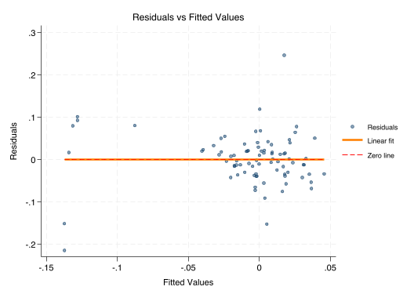

### Task 5.3: Breusch-Pagan Test

Perform the Breusch-Pagan test for heteroskedasticity.  
Question: What is the p-value? Do we reject the null hypothesis of homoskedasticity?

[figure not shown]

Stata Tip

After a regression, use `estat hettest` to perform the Breusch-Pagan test.

```
Breusch–Pagan/Cook–Weisberg test for heteroskedasticity
Assumption: Normal error terms
Variable: Fitted values of car_0_5

H0: Constant variance

    chi2(1) =  23.19
Prob > chi2 = 0.0000
✅ Breusch-Pagan test completed
```

### Test: Heteroskedasticity Diagnostics

```
✅ Heteroskedasticity diagnostics completed
```

## Section 6: Diagnostics - Normality

OLS assumes that errors are **normally distributed**. Let's test this assumption.

### Task 6.1: Histogram of Residuals

Create a histogram of the residuals with a normal distribution overlay. Save as histogram_residuals.png.  
Interpretation: If the histogram closely matches the normal curve, the normality assumption is reasonable.

[figure not shown]

Stata Tip

Use `histogram varname, normal` to create a histogram with normal density overlay.

```
(bin=9, start=-.21515974, width=.05122012)
file /Users/casparm4/Github/rsm-data-analytics-in-finance-private/private/assig
> nments/03-assignment/output/figures/histogram_residuals.png written in PNG fo
> rmat
✅ Residual histogram saved: histogram_residuals.png
```

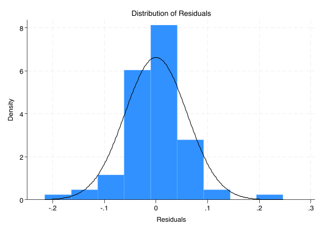

### Task 6.2: Shapiro-Wilk Test

Perform the Shapiro-Wilk test for normality on the residuals.  
Question: What is the p-value? Do we reject the null hypothesis of normality?

[figure not shown]

Stata Tip

Use `swilk varname` to perform the Shapiro-Wilk test for normality.

```
                   Shapiro–Wilk W test for normal data

    Variable |        Obs       W           V         z       Prob>z
-------------+------------------------------------------------------
       resid |         84    0.92648      5.253     3.644    0.00013
```

### Test: Normality Diagnostics

```
✅ Normality diagnostics completed
```

## Section 7: Robust Standard Errors

If heteroskedasticity is present, we should use **robust standard errors** (Huber-White standard errors) to get valid inference.

ℹ️ Background: Robust Standard Errors

**Robust (heteroskedasticity-consistent) standard errors** adjust for heteroskedasticity without changing coefficient estimates.  
**When to use**:

- Breusch-Pagan test rejects homoskedasticity (p < 0.05)
- Visual inspection of residual plots shows non-constant variance
- As a precaution in cross-sectional data (common practice)

**Effect**: Coefficients stay the same, but standard errors (and thus t-stats and p-values) change to be valid under heteroskedasticity.

### Task 7.1: Re-estimate with Robust Standard Errors

Re-estimate model 2 (with controls) using the robust option. Store as m3.  
Question: Did the standard errors change? Did the coefficients change?

[figure not shown]

Stata Tip

Add the `robust` option to the `regress` command: `regress y x, robust`

```
Linear regression                               Number of obs     =         84
                                                F(4, 79)          =       4.61
                                                Prob > F          =     0.0021
                                                R-squared         =     0.3149
                                                Root MSE          =     .06168

------------------------------------------------------------------------------
             |               Robust
     car_0_5 | Coefficient  std. err.      t    P>|t|     [95% conf. interval]
-------------+----------------------------------------------------------------
      german |    -.13205   .0480099    -2.75   0.007    -.2276113   -.0364886
      log_at |  -.0057776   .0016403    -3.52   0.001    -.0090425   -.0025126
    leverage |   .0303046   .0388468     0.78   0.438     -.047018    .1076272
         roa |   .0413695   .0601818     0.69   0.494    -.0784194    .1611583
       _cons |   .0543134   .0182133     2.98   0.004     .0180608    .0905661
------------------------------------------------------------------------------
✅ Model with robust SE (m3) estimated and stored
```

### Task 7.2: Compare All Three Models

Display all three models (m1, m2, m3) side-by-side using estimates table.

```
--------------------------------------------------------------
    Variable |      m1              m2              m3
-------------+------------------------------------------------
      german | -.12954665***   -.13204996***   -.13204996**
      log_at |                 -.00577757**    -.00577757***
    leverage |                  .03030462       .03030462
         roa |                  .04136945       .04136945
       _cons |  .00333977       .05431344*      .05431344**
-------------+------------------------------------------------
           N |         84              84              84
          r2 |  .24546842       .31493398       .31493398
--------------------------------------------------------------
                      Legend: * p<0.05; ** p<0.01; *** p<0.001
```

### Test: Robust Standard Errors Applied

```
✅ Robust standard errors applied successfully
```

## Section 8: Export Publication-Quality Regression Table

Now let's create a professional regression table using `esttab`.

### Task 8.1: Create LaTeX Regression Table

Use esttab to export all three models to a LaTeX file called regression_table.tex.  
Requirements:

- Include standard errors below coefficients
- Add significance stars (\*, **, \***)
- Include R² and number of observations
- Add appropriate variable labels

[figure not shown]

Stata Tip: esttab Options

Key `esttab` options:

- `se` — Include standard errors
- `star(* 0.10 ** 0.05 *** 0.01)` — Significance stars
- `stats(N r2)` — Add N and R²
- `label` — Use variable labels instead of names
- `replace` — Overwrite existing file

```
(output written to /Users/casparm4/Github/rsm-data-analytics-in-finance-private
> /private/assignments/03-assignment/output/tables/regression_table.tex)
✅ Regression table exported: regression_table.tex
```

### Test: Regression Table Exported

```
✅ Regression table created successfully
```

## Section 9: Interpretation and Conclusions

Finally, let's interpret our findings and discuss limitations.

### Task 9.1: Interpret Main Findings

In the markdown cell below, write 3-4 sentences interpreting your findings. Address:

- What is the **magnitude** of the German effect? (e.g., "German firms experienced X percentage points more negative returns...")
- Is this effect **statistically significant**?
- Did adding controls **change** the coefficient? What does this tell us?
- Based on the R², how much of the variation in CARs is explained by our model?

### Task 9.2: Discuss Limitations

In the markdown cell below, list 2-3 limitations of this analysis. Consider:

- Sample size
- Omitted variables
- Causality vs correlation
- Alternative explanations

**LIMITATIONS:**

1. **Small sample size**: With only 84 firms (7 German), our statistical power is limited, and results may be sensitive to outliers or individual firm characteristics.
2. **Omitted variable bias**: We control for basic firm fundamentals (size, leverage, profitability), but other important factors are missing—such as diesel exposure (% of sales from diesel vehicles), geographic revenue composition, or brand reputation—which could confound the German effect.
3. **Correlation vs causation**: While we find a strong association between German firm status and negative CARs, we cannot definitively claim causation. The effect could be driven by factors correlated with being German (e.g., regulatory exposure, media coverage) rather than German nationality per se. A more sophisticated identification strategy (e.g., difference-in-differences with non-automotive German firms as a control group) would strengthen causal claims.

```
✅ Assignment 3 complete! Review your interpretation and regression table.
```

## References

- **Fama-French Factors**: Kenneth French Data Library - https://mba.tuck.dartmouth.edu/pages/faculty/ken.french/data_library.html
- **Event Study Methodology**: MacKinlay, A. C. (1997). "Event Studies in Economics and Finance," *Journal of Economic Literature*, 35(1), 13-39
- **Dieselgate**: EPA Notice of Violation (September 18, 2015) - https://www.epa.gov/vw
- **Stata Documentation**: https://www.stata.com/features/documentation/
- **Robust Standard Errors**: White, H. (1980). "A Heteroskedasticity-Consistent Covariance Matrix Estimator," *Econometrica*, 48(4), 817-838

Data Analytics for Finance

BM17FI · Academic Year 2025–26

[figure not shown]

Created by: Caspar David Peter

© 2026 Rotterdam School of Management